# Can Holyavkin

# About Me

Bioinformatics analyst & molecular biologist with 6+ years of experience in next-generation sequencing data analysis & statistics in both clinical and R&D laboratories. Highly proficient with the analytic programming languages (Unix, R language, Python) and majority of analysis tools.

Strengths in data visualization, creative problem solving and troubleshooting. Experienced with large-scale genomic data analysis with over 50 academic and clinical projects that includes various approaches from de-novo transcriptome to metagenomic analysis.

# Work Experience

## Bioinformatics Analyst

**Company:** DONE Genetics and Bioinformatics Inc.  
**Period:** Jan 2013 - Present

Performed all basic and advanced analyses of both NGS based clinical and R&D projects using the current open source software. Development and benchmarking the pipelines for NGS data analysis including whole genome/exome sequencing, amplicon sequencing, RNA-seq, and ChIP-seq.

### Software Development

- Variant Navigator: Web-based variant filtering and reporting tool.
- Karyo Navigator: Web-based microarray data visualization tool.
- Observr: Interactive molecular karyotyping reports.
- QCReport: Interactive DNA quality control reports.

### Clinical Genetics Laboratory / Bioinformatics Operations

- Exome Sequencing
- Amplicon Sequencing

### R&D Laboratory / Bioinformatics Operations

- Metagenomics, Small Genome Seq.
- Microarray Genotyping , Expression
- Large-Scale Amplicon Sequencing

### R&D Laboratory / Consumer Genetics Test Development

- Carrier Status Test
- Sports Genetics
- Nutrition Genetics
- Pharmacogenetics
- Ancestry Genetics

### R&D Laboratory / Wet Lab Applications & NGS Panel Development

- 6+ Years Hands-on Experience on illumina NextSeq and MiSeq Platforms
- Development of Library Preparation Kits
- Development of Consumer Genetics Products

## R&D Scientist

**Company:** Sentromer DNA Technologies LLC  
**Period:** Jan 2012 - Jan 2013

- Synthetic oligonucleotide production and artificial gene synthesis
- Molecular kit development for GMO screening and pathogen detection

# Projects & Portfolio

## Variant Navigator

R Shiny based variant visualization and filtering tool..

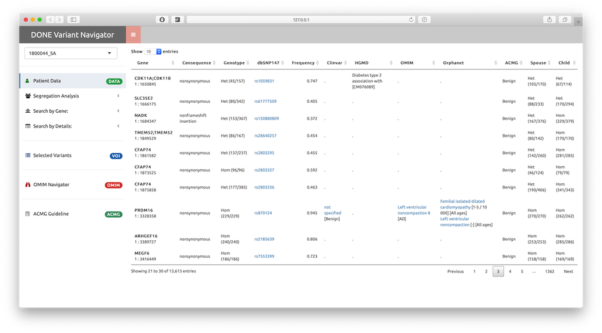

## Karyo Navigator

R Shiny based microarray based molecular karyotyping tool..

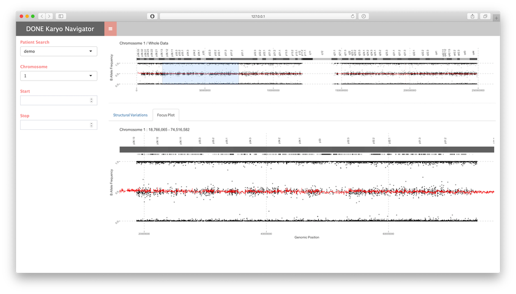

## ObservR

Automatic molecular karyotyping report generation tool based on illumina microarray platforms.

[figure not shown]

## QCReport

Automatic DNA QC report tool based on Nanodrop spectrophotometer.

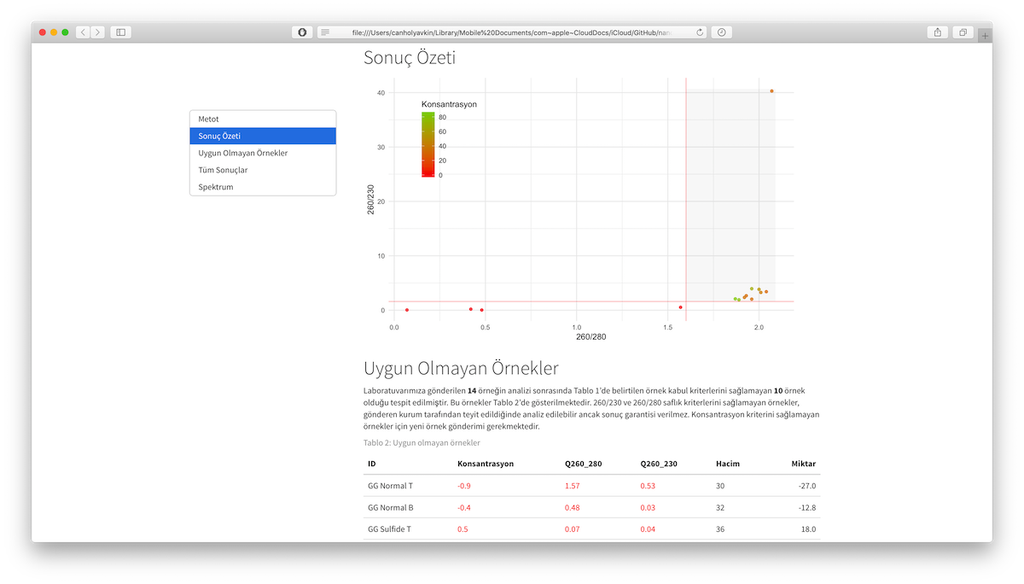

# Education

**Ph.D:** Istanbul Technical University (2/2013 – Present) Molecular Biology & Genetics and Biotechnology Department

**Ms.C:** Istanbul Technical University (9/2010 – 2/2013) Molecular Biology & Genetics and Biotechnology Department

**BSc.:** Istanbul Technical University (9/2006 – 9/2010) Molecular Biology & Genetics Department

# Publications

Arslan M, **Holyavkin C**, Kısakesen Hİ, Topaloğlu A, Sürmeli Y, Çakar ZP. 2018. Physiological and Transcriptomic Analysis of a Chronologically Long-Lived *Saccharomyces cerevisiae* Strain Obtained by Evolutionary Engineering. Molecular Biotechnology, 60: 468–484. http://dx.doi.org/10.1007/s12033-018-0087-2.

# Blog

## RKonsol

Turkish Blog about R Programming

**22 08 2018** ggplot Hakkında En Sık Sorulan Sorular  
**17 06 2018** Shiny Uygulamalarına Giriş  
**18 04 2018** 3 Kardeşler: apply, sapply ve lapply  
**09 12 2017** R’da Heatmap (Isı Haritası) Nasıl Oluşturulur?  
**16 02 2018** Benchmark Nasıl Yapılır?  
**12 11 2017** R ile Twitter’dan Nasıl Veri Çekilir?  
**20 10 2017** Ridgeline Plot Nasıl Oluşturulur?  
**22 09 2017** MillionSong: En Büyük Müzik Veriseti  
**12 09 2017** stringr: Yazı Düzenleme Paketi  
**31 08 2017** dplyr ile Veri Düzenlemeye Giriş  
**25 08 2017** rvest: R ile Web Sayfalarından Kolay Veri Çekimi  
**20 08 2017** ggplot ile Veri Görselleştirme  
**18 08 2017** R’ın İsveç Çakısı: Tidyverse  
**19 07 2017** R’da text (.txt) dosyası nasıl içeri aktarılır?

## Variant

Turkish Blog about Genomics

**08 07 2018** Samanlıktaki Mıknatıs: ClinVar  
**03 03 2018** Genomik ve Blockchain  
**04 10 2017** 10 Soruda Embriyoda CRISPR/Cas9 Uygulamaları  
**18 09 2017** Yeni Nesil Dizilemede Veri Kalite Kontrolü Nasıl Yapılır?  
**08 09 2017** İlk Sentetik Ökaryot: Sc2.0  
**23 08 2017** Referans Genom: Ne Kadar Güvenilir?  
**08 08 2017** Yeni Nesil Dizileme – Yeni Nesil Zorluklar  
**15 07 2017** DNA Dalgaboyu: 260nm  
**06 04 2017** JCVI-syn3.0: Minimal Genom Projesi